# MATH216 Assignment 3

Jay-Ho Chung

4/12/2020

# Instructions

- submit the .html file to Canvas
- you are encouraged to work together and ask your peers questions. Each person should submit their own work.
- You may share parts of your code to ask or answer questions on Slack. You should avoid sharing (copying and pasting) the entirety of your answers.
- make sure you include at least one acknowledgement
- Note that is question is worth 4 points. The assignment is worth 12 points total.

### Loading the data

```r
## maps
library(maps)
library(mapproj)
library(ggthemes)
library(RColorBrewer)
world_map <- map_data("world")  #to map countries in the world
states_map <- map_data("state") #to map states in the US
counties_map <-map_data("county") #to map counties in the US

## rnaturalearth
library(rnaturalearth)
worldmap <- ne_countries(scale = 'medium', type = 'map_units', returnclass = 'sf')
```

## Question 1: Display a map of the State of Vermont. The map should display all the counties in Vermont. Make sure your plot is well labeled. (Optional: put a marker where Middlebury College is located.)

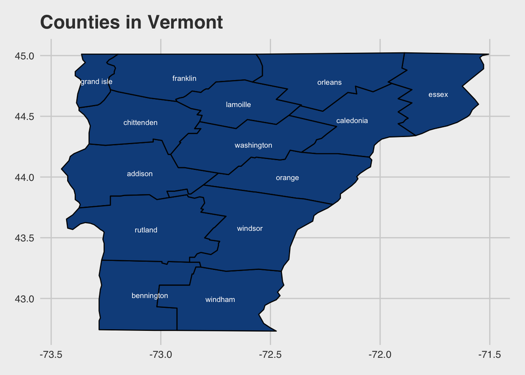

```r
vt <- map_data("county", region = "Vermont")


cnames <- aggregate(cbind(long, lat) ~ subregion, data= vt,
                    FUN=function(x)mean(range(x)))

ggplot(vt, aes(long, lat)) +
  geom_polygon(aes(group = group), fill = "dodgerblue4", color = "black") +
  geom_text(data= cnames, aes(long, lat, label = subregion), size=2.5, color = "white") +
  ggtitle("Counties in Vermont") +
  theme_fivethirtyeight()
```

## Question 2: Use `rnaturalearth` and the dataset `worldmap` to create a map of Africa. Shade the countries by the variable `economy` (contained within the `worldmap` dataset). Make sure your plot is well labeled.

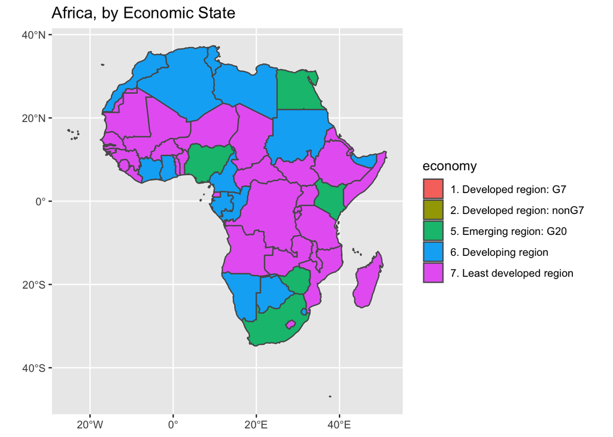

```r
africa <-worldmap %>%
  filter(continent == "Africa")

ggplot() +
  geom_sf(data = africa, aes(fill = economy)) +
  ggtitle("Africa, by Economic State")
```

## Question 3: The following should help you create a dataset `world_data` which contains information about many countries in the world. Create a map in an area of the world of your choice (ie. Africa, Caribbean, etc.) shading each of the countries using the variable `phones` which represents the number of phones per 1000 people. Make sure your plot is well labeled.

```r
#read in and format dataset
data <- read.csv("https://ebmwhite.github.io/MATH0216/data/worlddata.csv")
data$Country <- as.character(trimws(data$Country))
data$phones <- as.numeric(data$phones)

#format map data for joining
world_map$Country <- as.character(world_map$region)

#join map data with dataset
world_data <- left_join(world_map, data , by = "Country")
```

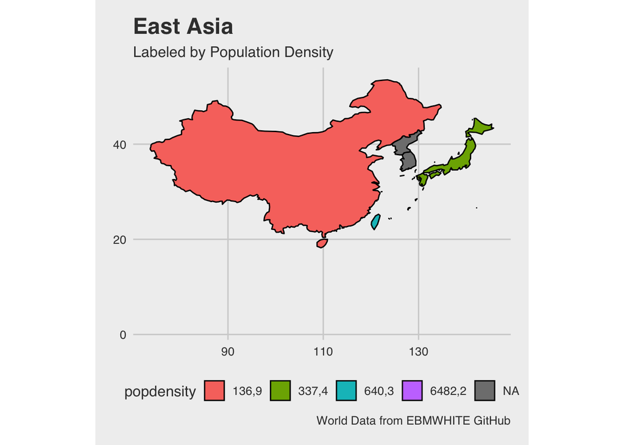

```r
#create a map!

east_asia <- c("South Korea",  "Japan", "China", "Taiwan", "Singapore", "North Korea")

ea <- world_data %>%
 filter( str_detect(region, east_asia))


ggplot(ea, aes(long, lat) ) +
  geom_polygon(aes(group = group, fill = popdensity), color = "#000000") +
  labs(title = "East Asia",
       subtitle = "Labeled by Population Density",
       caption = "World Data from EBMWHITE GitHub")+
  theme_fivethirtyeight() +
  coord_fixed(ratio = 1)
```

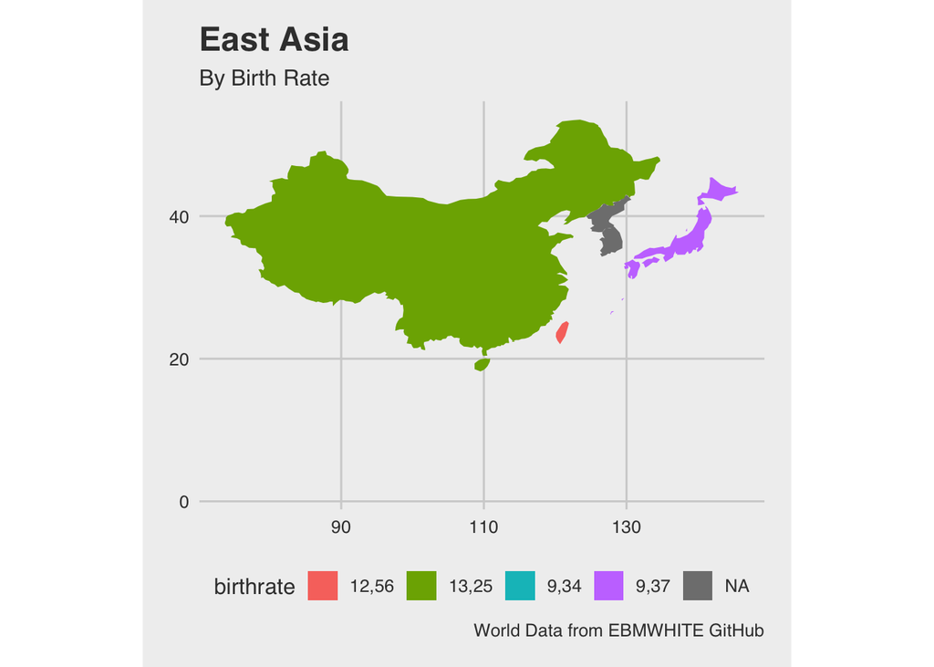

```r
ggplot(ea, aes(long, lat) ) +
  geom_polygon(aes(group = group, fill = birthrate)) +
    labs(title = "East Asia",
       subtitle = "By Birth Rate",
       caption = "World Data from EBMWHITE GitHub")+
  theme_fivethirtyeight() +
  coord_fixed(ratio = 1)
```

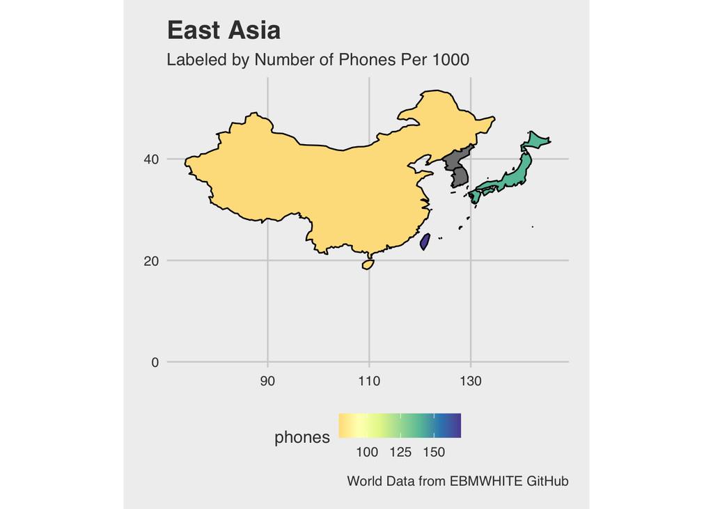

```r
ggplot(ea, aes(long, lat) ) +
  geom_polygon(aes(group = group, fill = phones), color = "#000000") +
  labs(title = "East Asia",
       subtitle = "Labeled by Number of Phones Per 1000",
       caption = "World Data from EBMWHITE GitHub")+
  theme_fivethirtyeight() +
  coord_fixed(ratio = 1)  +
  scale_fill_gradientn(colors = brewer.pal(11, "Spectral")[5:11] )
```

I just included population density and birth rate as some fun things to look into.

# Acknowledgements

Thank you so much to Professor Malcolm-White for her help. I honestly ran into so many issues with the maps module, and she was with me every step of the way.